# AoL_DMV

2024-06-02

We decide to use 3 dataset as we want to try to analyze the correlation between air pollution in jakarta, green area and the ownership of private vehicle in Jakarta. As jakarta felt very gray and very hot, and the street is always packed, we want to know whether they have correlation to each other The SDG we choose for this project are 11th “Sustainable Cities and Communities”, 13th “Climate Action” and 15th “Life on Land”

```r
setwd("C:/Kuliah/Semester 2/DMV/AoL Project")

dfcar <- read.csv("JmlhKendaraanBermotor_Jakarta.csv")
dfgreen <- read.csv("Jmlh_Lapangan_Terbuka_Hijau.csv")
dfpolut <- read.csv("IndeksPencemaranUdara_Jakarta.csv")
```

```r
print(dfcar)
```

```
##   Jenis.Kendaraan    X2020    X2021    X2022
## 1 Mobil Penumpang  3365467  3544491  3766059
## 2             Bus    35266    36339    37180
## 3            Truk   679708   713059   748395
## 4    Sepeda Motor 16141380 16711638 17304447
## 5          Jumlah 20221821 21005527 21856081
```

```r
print(dfgreen)
```

```
##           Kota.Adm                                Jenis Jumlah    Luas
## 1      Kep. Seribu      Taman Kota dan Taman Lingkungan     NA      NA
## 2      Kep. Seribu                     Taman Interaktif     NA      NA
## 3      Kep. Seribu                  Taman/Bangunan Umum     NA      NA
## 4      Kep. Seribu                       Taman Rekreasi     NA      NA
## 5      Kep. Seribu       Jalur Hijau Jalan & Pedestrian     NA      NA
## 6      Kep. Seribu Jalur Hijau Tepian Air & Penyempurna     NA      NA
## 7      Kep. Seribu                      Taman Pemakaman      5   44995
## 8      Kep. Seribu              Taman Eks Refungsi SPBU     NA      NA
## 9  Jakarta Selatan      Taman Kota dan Taman Lingkungan    596 3969676
## 10 Jakarta Selatan                     Taman Interaktif     20   81113
## 11 Jakarta Selatan                  Taman/Bangunan Umum      4    3783
## 12 Jakarta Selatan                       Taman Rekreasi      6  224315
## 13 Jakarta Selatan       Jalur Hijau Jalan & Pedestrian     26  354242
## 14 Jakarta Selatan Jalur Hijau Tepian Air & Penyempurna     17  142422
```

[output cut: 34 more lines]

We only need the 2021 year data as all of the data are from 2021 (outdated perhaps, but still SDG)

```r
subsetcar <- dfcar[c(1,3)]
subsetcar
```

```
##   Jenis.Kendaraan    X2021
## 1 Mobil Penumpang  3544491
## 2             Bus    36339
## 3            Truk   713059
## 4    Sepeda Motor 16711638
## 5          Jumlah 21005527
```

```r
unique(dfgreen$Jenis)
```

```
## [1] "Taman Kota dan Taman Lingkungan"
## [2] "Taman Interaktif"
## [3] "Taman/Bangunan Umum"
## [4] "Taman Rekreasi"
## [5] "Jalur Hijau Jalan & Pedestrian"
## [6] "Jalur Hijau Tepian Air & Penyempurna"
## [7] "Taman Pemakaman"
## [8] "Taman Eks Refungsi SPBU"
```

We also make sure that we only gather data for green open space, so we filter the dataframe

```r
subsetgreen <- dfgreen[dfgreen$Jenis %in% c("Taman Kota dan Taman Lingkungan", "Taman Interaktif", "Jalur Hijau Jalan & Pedestrian", "Jalur Hijau Tepian Air & Penyempurna") & dfgreen$Kota.Adm != "Kep. Seribu", ]
subsetgreen
```

```
##           Kota.Adm                                Jenis Jumlah    Luas
## 9  Jakarta Selatan      Taman Kota dan Taman Lingkungan    596 3969676
## 10 Jakarta Selatan                     Taman Interaktif     20   81113
## 13 Jakarta Selatan       Jalur Hijau Jalan & Pedestrian     26  354242
## 14 Jakarta Selatan Jalur Hijau Tepian Air & Penyempurna     17  142422
## 17   Jakarta Timur      Taman Kota dan Taman Lingkungan    425 3660514
## 18   Jakarta Timur                     Taman Interaktif     30   92609
## 21   Jakarta Timur       Jalur Hijau Jalan & Pedestrian      3   16554
## 22   Jakarta Timur Jalur Hijau Tepian Air & Penyempurna      9  417228
## 25   Jakarta Pusat      Taman Kota dan Taman Lingkungan    436 4451434
## 26   Jakarta Pusat                     Taman Interaktif     18    6299
## 29   Jakarta Pusat       Jalur Hijau Jalan & Pedestrian     53  322682
## 30   Jakarta Pusat Jalur Hijau Tepian Air & Penyempurna     18  239065
## 33   Jakarta Barat      Taman Kota dan Taman Lingkungan    329 3527653
## 34   Jakarta Barat                     Taman Interaktif     15   10295
## 37   Jakarta Barat       Jalur Hijau Jalan & Pedestrian      6   37121
## 38   Jakarta Barat Jalur Hijau Tepian Air & Penyempurna      5   51426
## 41   Jakarta Utara      Taman Kota dan Taman Lingkungan    365 3628160
## 42   Jakarta Utara                     Taman Interaktif     18   15324
## 45   Jakarta Utara       Jalur Hijau Jalan & Pedestrian      3   27090
## 46   Jakarta Utara Jalur Hijau Tepian Air & Penyempurna      3   74506
```

Using the dpylr library to use piping, we count the total area of the green area in Jakarta for further analysis, we’re planning to compare it to total area of jakarta and see how many percentage are the green compared to the gray, then to visualize this in the poster (graphical visualization) we’ll choose a map

```r
library(dplyr)
totalgreen <- subsetgreen %>%
  group_by(Kota.Adm) %>%
  summarise(Total_Jumlah = sum(Jumlah), Total_Luas = sum(Luas))

latitude <- c(-6.2088, -6.1894, -6.2615, -6.2297, -6.1396)
longitude <- c(106.7831, 106.8323, 106.8106, 106.8701, 106.8827)

totalgreen$Latitude <- latitude
totalgreen$Longitude <- longitude

totalgreen
```

```
## # A tibble: 5 × 5
##   Kota.Adm        Total_Jumlah Total_Luas Latitude Longitude
##   <chr>                  <int>      <int>    <dbl>     <dbl>
## 1 Jakarta Barat            355    3626495    -6.21      107.
## 2 Jakarta Pusat            525    5019480    -6.19      107.
## 3 Jakarta Selatan          659    4547453    -6.26      107.
## 4 Jakarta Timur            467    4186905    -6.23      107.
## 5 Jakarta Utara            389    3745080    -6.14      107.
```

As the January one do not have data for PM25, i suppose we might just exclude January from our analysis

```r
dfpolut$Tanggal <- as.Date(dfpolut$tanggal, format = "%m/%d/%Y")

start_date <- as.Date("2021-01-01")
end_date <- as.Date("2021-01-31")

subsetpolut <- dfpolut[!(dfpolut$Tanggal >= start_date & dfpolut$Tanggal  <= end_date), ]

print(subsetpolut)
```

```
##        tanggal pm10 pm25 so2 co  o3 no2 max critical    categori location
## 32    2/1/2021   73  126  38 26  46  34 126     PM25 TIDAK SEHAT     DKI5
## 33    2/2/2021   53   70  40 14  55  25  70     PM25      SEDANG     DKI3
## 34    2/3/2021   32   53  40 11  42  19  53     PM25      SEDANG     DKI3
## 35    2/4/2021   36   59  40 14  47  24  59     PM25      SEDANG     DKI5
## 36    2/5/2021   29   51  40 14  45  35  51     PM25      SEDANG     DKI3
## 37    2/6/2021   34   53  40  8  57  15  57       O3      SEDANG     DKI2
## 38    2/7/2021   33   55  40 10  57  13  57       O3      SEDANG     DKI2
## 39    2/8/2021   26   44  39 10  54  17  54       O3      SEDANG     DKI2
## 40    2/9/2021   33   57  40 13  47  22  57     PM25      SEDANG     DKI4
## 41   2/10/2021   50   64  40 13  49  16  64     PM25      SEDANG     DKI3
## 42   2/11/2021   38   57  43 13  35  17  57     PM25      SEDANG     DKI3
## 43   2/12/2021   63   98  43 16  33  42  98     PM25      SEDANG     DKI3
## 44   2/13/2021   59   89  40 12  40  16  89     PM25      SEDANG     DKI3
## 45   2/14/2021   55   73  40 11  42  19  73     PM25      SEDANG     DKI3
```

[output cut: 655 more lines]

We try to find missing value but we don’t get any

```r
colSums(is.na(subsetpolut))
```

```
##  tanggal     pm10     pm25      so2       co       o3      no2      max
##        0        0        0        0        0        0        0        0
## critical categori location  Tanggal
##        0        0        0        0
```

After that we also try to find outlier and from the dot, and certainly there are outliers

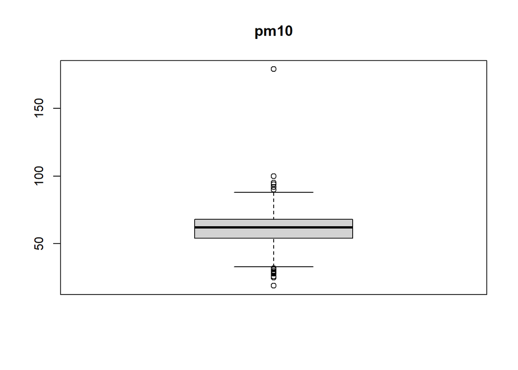

```r
boxplot(subsetpolut$pm10, main = "pm10")
```

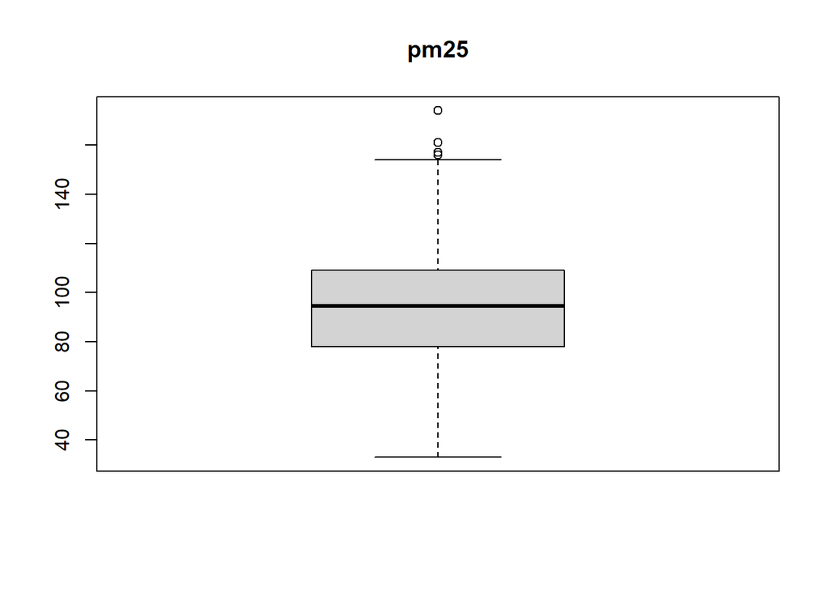

```r
boxplot(subsetpolut$pm25, main = "pm25")
```

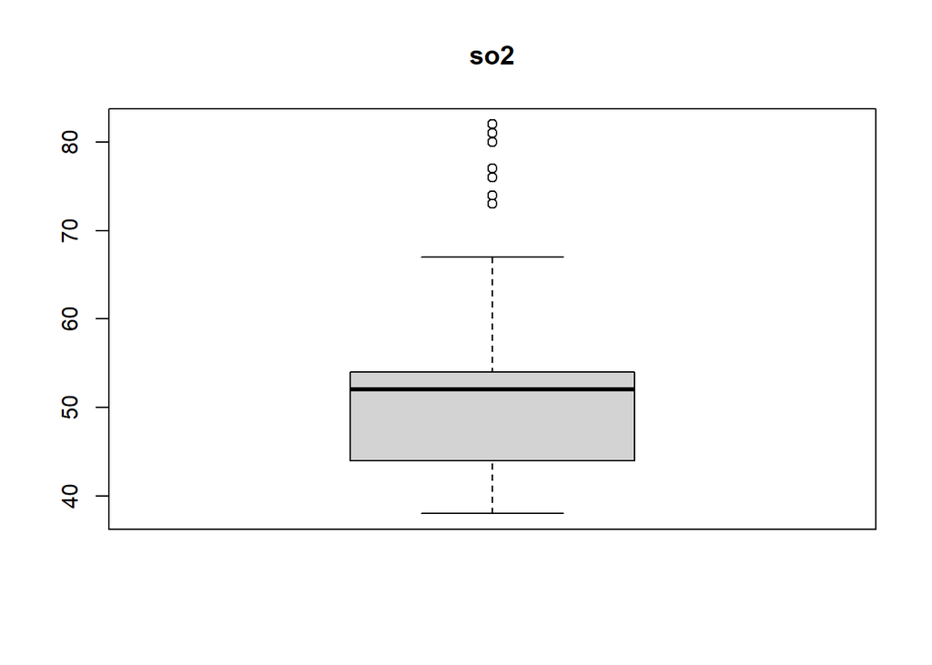

```r
boxplot(subsetpolut$so2, main = "so2")
```

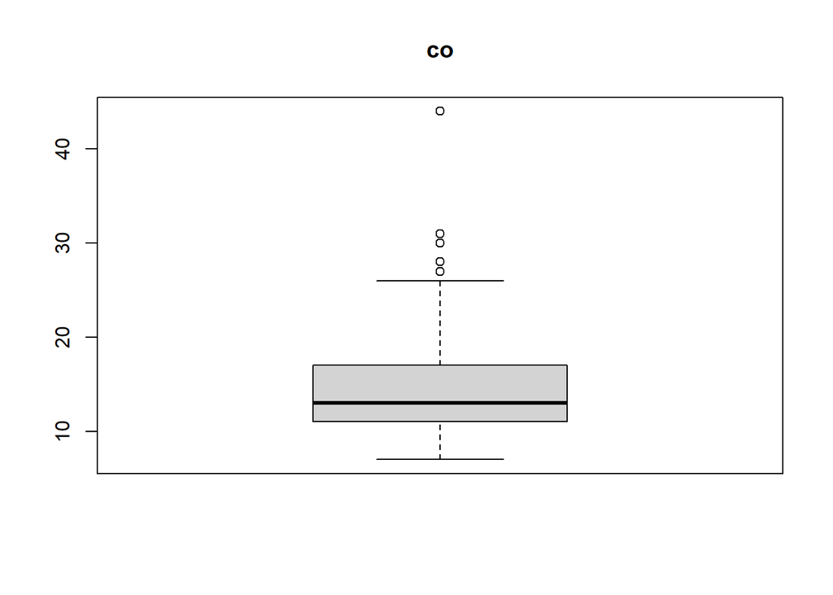

```r
boxplot(subsetpolut$co, main = "co")
```

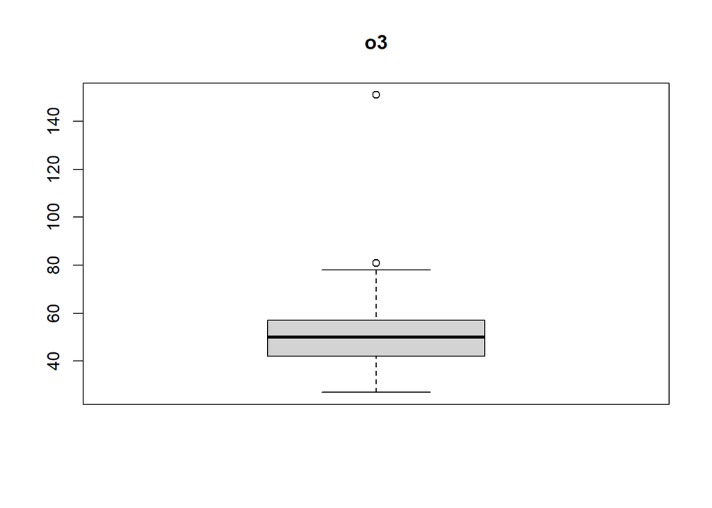

```r
boxplot(subsetpolut$o3, main = "o3")
```

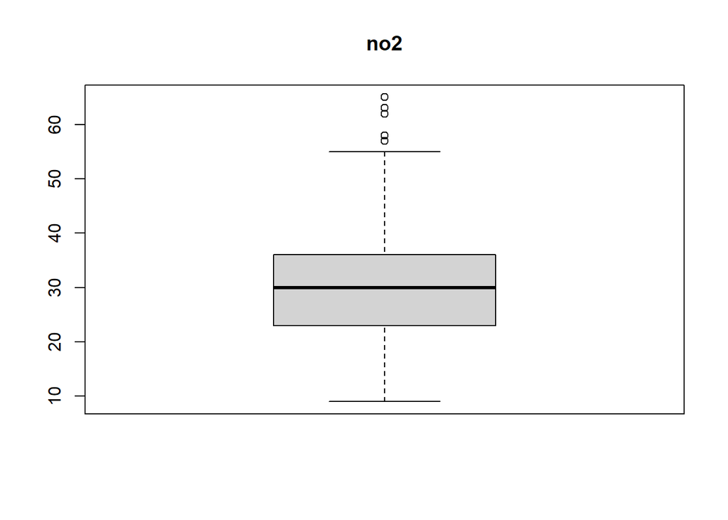

```r
boxplot(subsetpolut$no2, main = "no2")
```

```r
numpolut <- subsetpolut[,c(2:7)]

Outlier <- function(x, thres = 1.5){
  Q1 <- quantile(x, 0.25)
  Q3 <- quantile(x, 0.75)
  IQR_Value <- IQR(x)
  lower_bound <- Q1 - thres*IQR_Value
  upper_bound <- Q3 + thres*IQR_Value
  outliers <- x[x < lower_bound | x > upper_bound]
  return(outliers)
}

outlier_count <-sapply(numpolut, function(x) length(Outlier(x)))
print(outlier_count)
```

```
## pm10 pm25  so2   co   o3  no2
##   18    4    8    8    2    5
```

We already try to impute the outlier as our handling method but it didn’t work quite well as it made the data become bias to certain critical category, and we cannot delete it because of the monthly data so we might just let them there

We label the DKI1 - DKI5 as the location, DKI is the SPKU location and it’s scattered each on one region in Jakarta

```r
library(dplyr)

location_label <- c("DKI1" = "Jakarta Pusat", "DKI2" = "Jakarta Utara", "DKI3" = "Jakarta Selatan", "DKI4" = "Jakarta Timur", "DKI5" = "Jakarta Barat")

subsetpolut <- subsetpolut %>%
  mutate(location = case_when(
    location == "DKI1" ~ "Jakarta Pusat",
    location == "DKI2" ~ "Jakarta Utara",
    location == "DKI3" ~ "Jakarta Selatan",
    location == "DKI4" ~ "Jakarta Timur",
    location == "DKI5" ~ "Jakarta Barat",
    TRUE ~ as.character(location)
  ))

subsetpolut
```

```
##        tanggal pm10 pm25 so2 co  o3 no2 max critical    categori
## 32    2/1/2021   73  126  38 26  46  34 126     PM25 TIDAK SEHAT
## 33    2/2/2021   53   70  40 14  55  25  70     PM25      SEDANG
## 34    2/3/2021   32   53  40 11  42  19  53     PM25      SEDANG
## 35    2/4/2021   36   59  40 14  47  24  59     PM25      SEDANG
## 36    2/5/2021   29   51  40 14  45  35  51     PM25      SEDANG
## 37    2/6/2021   34   53  40  8  57  15  57       O3      SEDANG
## 38    2/7/2021   33   55  40 10  57  13  57       O3      SEDANG
## 39    2/8/2021   26   44  39 10  54  17  54       O3      SEDANG
## 40    2/9/2021   33   57  40 13  47  22  57     PM25      SEDANG
## 41   2/10/2021   50   64  40 13  49  16  64     PM25      SEDANG
## 42   2/11/2021   38   57  43 13  35  17  57     PM25      SEDANG
## 43   2/12/2021   63   98  43 16  33  42  98     PM25      SEDANG
## 44   2/13/2021   59   89  40 12  40  16  89     PM25      SEDANG
## 45   2/14/2021   55   73  40 11  42  19  73     PM25      SEDANG
```

[output cut: 655 more lines]

Here we count how many each critical occured to each location, but as this data is mostly filled with DKI4, we cannot consider this as the most useful insight because of the data bias

```r
critpolut <- subsetpolut %>% group_by(location) %>%
  summarise(
    pm10 = sum(critical == "PM10", na.rm = TRUE),
    pm25 = sum(critical == "PM25", na.rm = TRUE),
    so2 = sum(critical == "SO2", na.rm = TRUE),
    co = sum(critical == "CO", na.rm = TRUE),
    o3 = sum(critical == "O3", na.rm = TRUE),
    no2 = sum(critical == "NO2", na.rm = TRUE)
  )

critpolut
```

```
## # A tibble: 5 × 7
##   location         pm10  pm25   so2    co    o3   no2
##   <chr>           <int> <int> <int> <int> <int> <int>
## 1 Jakarta Barat       0    31     0     0     0     0
## 2 Jakarta Pusat       0     1     0     0     0     0
## 3 Jakarta Selatan     0    43     0     0     1     0
## 4 Jakarta Timur       1   224     0     0     0     0
## 5 Jakarta Utara       1    26     1     0     4     0
```

and this is how many each SPKU contributed to the 334 days of the dataframe

```r
contribution <- subsetpolut %>%
  group_by(location) %>%
  summarise(contributions = n())

contribution
```

```
## # A tibble: 5 × 2
##   location        contributions
##   <chr>                   <int>
## 1 Jakarta Barat              31
## 2 Jakarta Pusat               1
## 3 Jakarta Selatan            44
## 4 Jakarta Timur             226
## 5 Jakarta Utara              32
```

this is just the horizontal version

```r
critpolut2 <- subsetpolut %>% group_by(critical) %>%
  summarise(
    JakBar= sum(location == "Jakarta Barat", na.rm = TRUE),
    JakTim = sum(location == "Jakarta Timur", na.rm = TRUE),
    JakPus = sum(location == "Jakarta Pusat", na.rm = TRUE),
    JakUt = sum(location == "Jakarta Utara", na.rm = TRUE),
    JakSel = sum(location == "Jakarta Selatan", na.rm = TRUE),
  )

critpolut2
```

```
## # A tibble: 5 × 6
##   critical JakBar JakTim JakPus JakUt JakSel
##   <chr>     <int>  <int>  <int> <int>  <int>
## 1 O3            0      0      0     4      1
## 2 PM10          0      1      0     1      0
## 3 PM25         31    224      1    26     43
## 4 PM26          0      1      0     0      0
## 5 SO2           0      0      0     1      0
```

Here we use mutate function to change the date formatting, because we want to harvest the monthly information of each pollutant critical occurence, and turns out PM5 is still dominating

```r
subsetpolut <- subsetpolut %>%
  mutate(month = format(Tanggal, "%Y-%m"))

critical_counts_monthly <- subsetpolut %>%
  group_by(month) %>%
  summarise(
    pm10 = sum(critical == "PM10", na.rm = TRUE),
    pm25 = sum(critical == "PM25", na.rm = TRUE),
    so2 = sum(critical == "SO2", na.rm = TRUE),
    co = sum(critical == "CO", na.rm = TRUE),
    o3 = sum(critical == "O3", na.rm = TRUE),
    no2 = sum(critical == "NO2", na.rm = TRUE)
  )

print(critical_counts_monthly)
```

```
## # A tibble: 11 × 7
##    month    pm10  pm25   so2    co    o3   no2
##    <chr>   <int> <int> <int> <int> <int> <int>
##  1 2021-02     0    25     0     0     3     0
##  2 2021-03     0    31     0     0     0     0
##  3 2021-04     0    30     0     0     0     0
##  4 2021-05     0    30     0     0     1     0
##  5 2021-06     0    30     0     0     0     0
##  6 2021-07     1    29     0     0     0     0
##  7 2021-08     0    31     0     0     0     0
##  8 2021-09     0    30     0     0     0     0
##  9 2021-10     0    30     1     0     0     0
## 10 2021-11     0    29     0     0     1     0
## 11 2021-12     1    30     0     0     0     0
```

we want to see how many pollution of each category have been recorded at each location and count the total of each category

```r
category_counts <- subsetpolut %>%
  group_by(location, categori) %>%
  summarise(count = n())
print(category_counts)
```

```
## # A tibble: 11 × 3
## # Groups:   location [5]
##    location        categori    count
##    <chr>           <chr>       <int>
##  1 Jakarta Barat   SEDANG         21
##  2 Jakarta Barat   TIDAK SEHAT    10
##  3 Jakarta Pusat   SEDANG          1
##  4 Jakarta Selatan SEDANG         34
##  5 Jakarta Selatan TIDAK SEHAT    10
##  6 Jakarta Timur   BAIK            1
##  7 Jakarta Timur   SEDANG        111
##  8 Jakarta Timur   TIDAK SEHAT   114
##  9 Jakarta Utara   BAIK            2
## 10 Jakarta Utara   SEDANG         28
## 11 Jakarta Utara   TIDAK SEHAT     2
```

```r
categories <- subsetpolut %>%
  group_by(categori) %>%
  summarise(count = n())

print(categories)
```

```
## # A tibble: 3 × 2
##   categori    count
##   <chr>       <int>
## 1 BAIK            3
## 2 SEDANG        195
## 3 TIDAK SEHAT   136
```

we want to know how many pollutions event have been recorded in each month at every location

```r
month_counts <- subsetpolut %>%
  group_by(month, location) %>%
  summarise(count = n())
print(month_counts)
```

```
## # A tibble: 42 × 3
## # Groups:   month [11]
##    month   location        count
##    <chr>   <chr>           <int>
##  1 2021-02 Jakarta Barat       5
##  2 2021-02 Jakarta Selatan    12
##  3 2021-02 Jakarta Timur       8
##  4 2021-02 Jakarta Utara       3
##  5 2021-03 Jakarta Barat       6
##  6 2021-03 Jakarta Selatan    11
##  7 2021-03 Jakarta Timur      13
##  8 2021-03 Jakarta Utara       1
##  9 2021-04 Jakarta Barat       6
## 10 2021-04 Jakarta Selatan     5
## # ℹ 32 more rows
```

we merge the susetgreen and category-count by the location so that we can see the green area, the condition of that location, and the type of place occurrance more easily

```r
colnames(subsetgreen) <- c("location","jenis", "jumlah", "luas")

greenmonth <- merge(subsetgreen, category_counts, by = "location", all.x = T)
greenmonth
```

```
##           location                                jenis jumlah    luas
## 1    Jakarta Barat      Taman Kota dan Taman Lingkungan    329 3527653
## 2    Jakarta Barat      Taman Kota dan Taman Lingkungan    329 3527653
## 3    Jakarta Barat                     Taman Interaktif     15   10295
## 4    Jakarta Barat                     Taman Interaktif     15   10295
## 5    Jakarta Barat       Jalur Hijau Jalan & Pedestrian      6   37121
## 6    Jakarta Barat       Jalur Hijau Jalan & Pedestrian      6   37121
## 7    Jakarta Barat Jalur Hijau Tepian Air & Penyempurna      5   51426
## 8    Jakarta Barat Jalur Hijau Tepian Air & Penyempurna      5   51426
## 9    Jakarta Pusat      Taman Kota dan Taman Lingkungan    436 4451434
## 10   Jakarta Pusat                     Taman Interaktif     18    6299
## 11   Jakarta Pusat       Jalur Hijau Jalan & Pedestrian     53  322682
## 12   Jakarta Pusat Jalur Hijau Tepian Air & Penyempurna     18  239065
## 13 Jakarta Selatan      Taman Kota dan Taman Lingkungan    596 3969676
## 14 Jakarta Selatan      Taman Kota dan Taman Lingkungan    596 3969676
```

[output cut: 75 more lines]

```r
library(ggplot2)
```

this is the bar plot of every types of vehicles in 2021

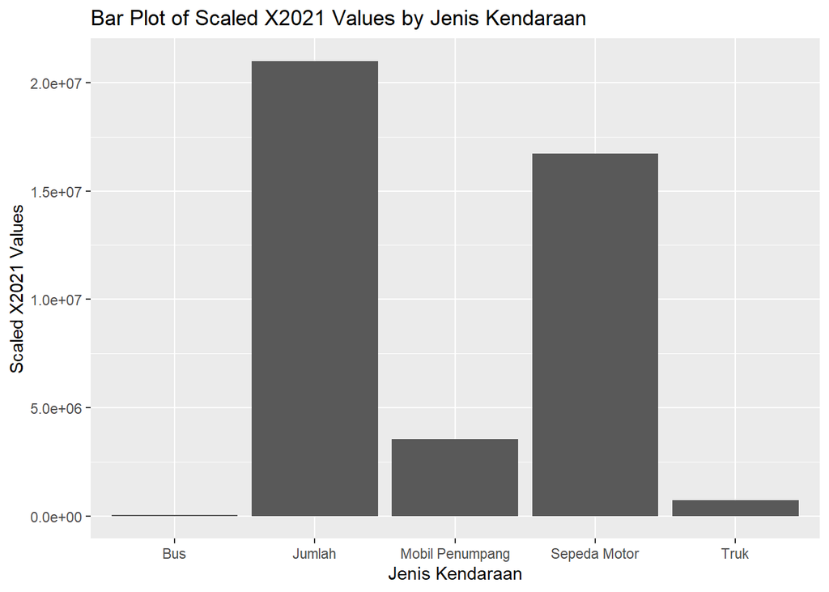

```r
ggplot(subsetcar, aes(x = Jenis.Kendaraan, y = X2021)) +
  geom_bar(stat = "identity") +
  labs(y = "Scaled X2021 Values", x = "Jenis Kendaraan") +
  ggtitle("Bar Plot of Scaled X2021 Values by Jenis Kendaraan")
```

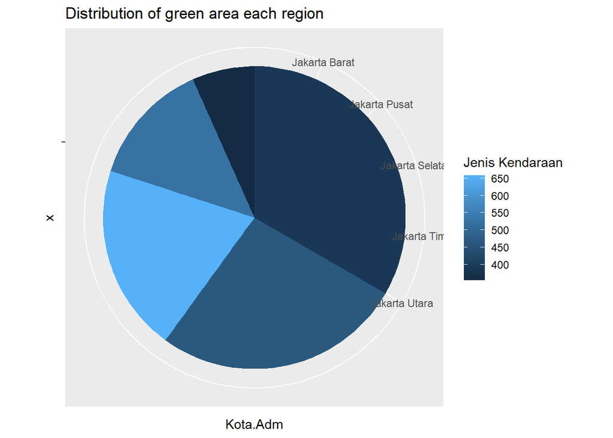

```r
ggplot(totalgreen, aes(x = "", y = Kota.Adm, fill = Total_Jumlah)) + geom_bar(width = 1, stat = "identity") + coord_polar(theta = "y") + labs(fill = "Jenis Kendaraan") + ggtitle("Distribution of green area each region")
```

and this is the pie chart of pollution level in Jakarta

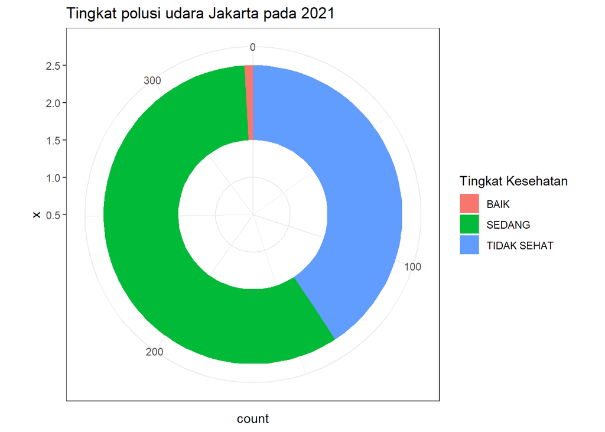

```r
ggplot(categories, aes(x = 2, y = count, fill = categori)) + geom_bar(stat = "identity", width = 1) + coord_polar(theta = "y", start = 0) + geom_bar(stat = "identity", width = 0.5, aes(y=0)) + xlim(0.5, 2.5) + labs(fill = "Tingkat Kesehatan") + theme_bw() + ggtitle("Tingkat polusi udara Jakarta pada 2021")
```

we want to see the SPKU contribution in each region

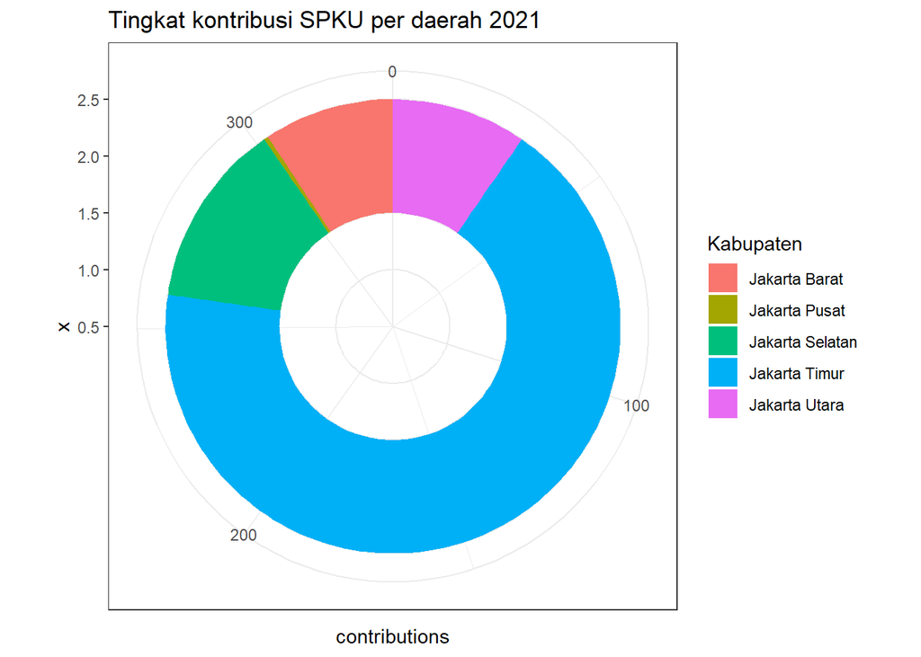

```r
ggplot(contribution, aes(x = 2, y = contributions, fill = location)) + geom_bar(stat = "identity", width = 1) + coord_polar(theta = "y", start = 0) + geom_bar(stat = "identity", width = 0.5, aes(y=0)) + xlim(0.5, 2.5) + labs(fill = "Kabupaten") + theme_bw() + ggtitle("Tingkat kontribusi SPKU per daerah 2021")
```

and this is the monthly contribution, in here we can see that SPKU mainlu focuses in Jakarta Timur than the other region

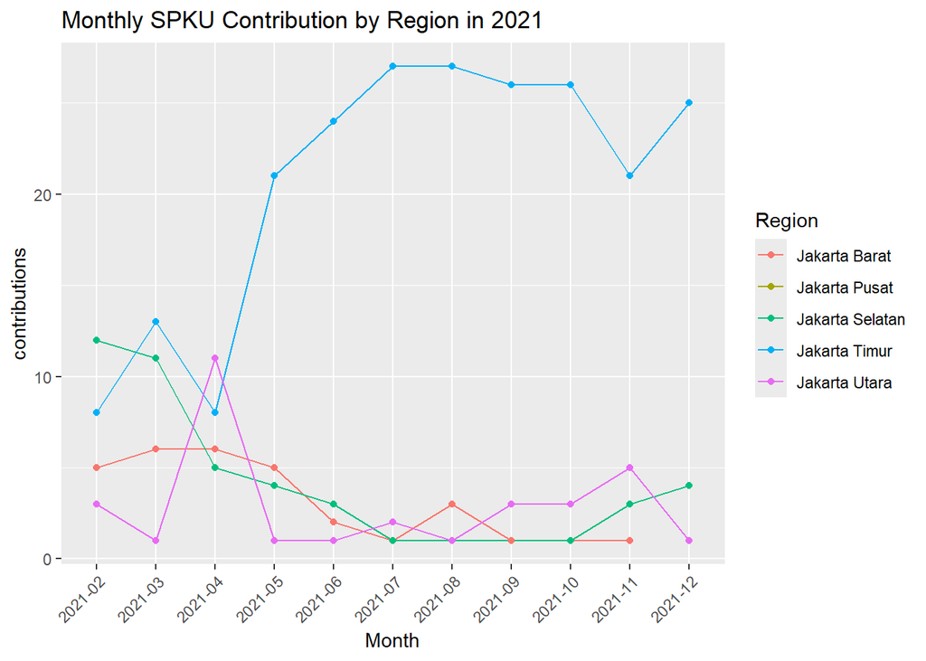

```r
ggplot(month_counts, aes(x = month, y = count, color = location, group = location)) + geom_line() + geom_point() + labs (x = "Month", y = "contributions", title = "Monthly SPKU Contribution by Region in 2021", color = "Region") + theme(axis.text.x = element_text(angle = 45, hjust = 1))
```

we want to see the occurrence of air pollution levels in each region in 2021

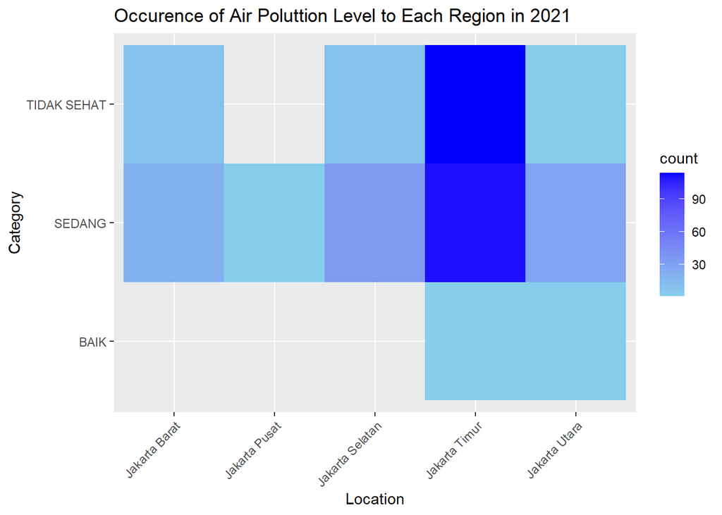

```r
ggplot(category_counts, aes(x = location, y = categori, fill = count)) + geom_tile() + scale_fill_gradient(low= "skyblue", high = "blue") + labs(x = "Location", y = "Category", title = "Occurence of Air Poluttion Level to Each Region in 2021") + theme(axis.text.x = element_text(angle = 45, hjust = 1))
```

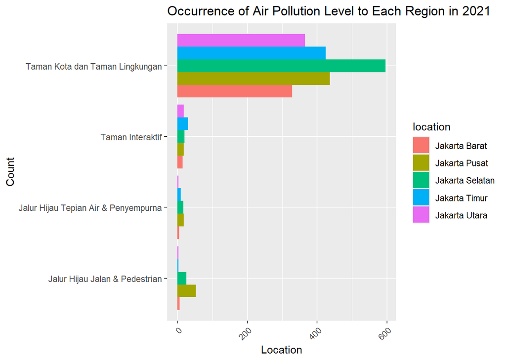

```r
ggplot(greenmonth, aes(y = jenis, x = jumlah, fill = location)) +
  geom_bar(stat = "identity", position = "dodge") +
  labs(x = "Location", y = "Count", title = "Occurrence of Air Pollution Level to Each Region in 2021") +
  theme(axis.text.x = element_text(angle = 45, hjust = 1))
```

```r
library(ggmap)
```

we want to show the mapping of the total population in Jakarta but the API didn’t work, we comment it so we can knit the file

map <- get_map(location = “Jakarta”, zoom = 11)

ggmap(map) + geom_point(data = totalgreen, aes(x = Longitude, y = Latitude, size = Total_Jumlah), color = “green”, alpha = 0.8) + labs(title = “Total Population by Region in Jakarta”) + scale_size_continuous(name = “Total Population”) + theme(legend.position = “bottom”) + theme(axis.title = element_blank())